# Stat 297: Used car data project

Daniel Lee

# Introduction and directions

The purpose of this project is to give you experience sourcing, reading, and using real data to answer research questions using simple linear regression. You should refer back to your previous homework assignments and R notebooks used in lecture for the relevant R codes. You are also encouraged to get help from your instructor and TA during office hours.

## Collaboration rules:

You may consult with up to two classmates for help with this project, but use your own data. Please identify who you collaborate with here.

## Project premise

Let’s assume you are interested in purchasing a used car and you want to use data to help you research what you could consider a ‘fair price’. Obviously, the price of a car depends on many things, including the car’s age, mileage, condition, make, and model. At this time, we only have the tools to consider one predictor variable at a time so you will be using the variable ‘age’ to predict the price of used cars.

For this project you will source a new, never seen before dataset by scraping observations from autotrader.com for a make and model of your choosing. You’ll want to ultimately have a dataset of 50 cars, so when you obtain the data ask for a sample of size 60 in case you end up needing to eliminate some of the observations.

To get your data, go to http://myslu.stlawu.edu/~clee/dataset/autotrader/, choose the make and model, input a zip code, and ask for 60 observations. If you are choosing a more rare type of car it might be difficult to get 60 observations for certain zip codes. Try a zip code close to a big city like Boston (02124), Los Angeles (90010), or Chicago (60176). Save the data and choose a name for the dataset with a .csv extension. After you save the data, you should check the spreadsheet for any cases that should be deleted. For example, sometimes new cars will be included (mileage of 0), or odd entries with a price of 0 will appear. Delete these types of cases, and then continue deleting random observations until you have a dataset of size 50.

You should have a dataset with variables ‘year’, ‘price’ (in $1,000’s), and ‘mileage’ (in 1,000’s) ready to load into R. Run the front-matter below to load your data into the workspace and load the packages you are most likely to need for this project.

[output not shown]

# Project

Introduce your data using complete sentences. What kind of car are you looking at? Where did these car listings come from (zip code and town)?

I am looking at Hyundai Sonata cars with a zip code of 02124 which is Boston.

## Model: Choose

Use R to compute each of the summary statistics below, writing them in the text next to their names.

- average age: 4.216667
- standard deviation of age: 1.814178
- average price: 13.38638
- standard deviation of price: 2.996808

```r
mean(~ age, data = used_cars)
```

```
[1] 4.216667
```

```r
sd(~ age, data = used_cars, na.rm=T)
```

```
[1] 1.814178
```

```r
mean(~ price, data = used_cars)
```

```
[1] 13.38638
```

```r
sd(~ price, data = used_cars, na.rm=T)
```

```
[1] 2.996808
```

Produce a scatterplot of the relationship between age and price with the regression line drawn on top. What do you observe?

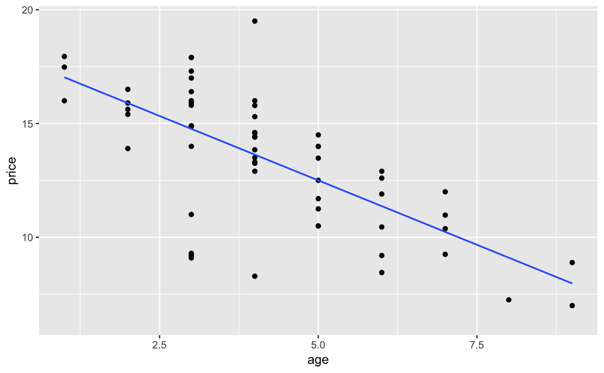

```r
gf_point(price ~age, data = used_cars) %>%
  gf_lm()
```

I see a negative association between age and price. This can be interpreted as age of the car increases, the price of the car decreases.

## Model: Fit

Fit a simple linear model to your data. Use R to compute each of the summary statistics below, writing them in the text next to their names.

Interpret, in context, what the slope estimate tells you about age and price in your used car model. Make sure you add a sentence about why the sign (positive or negative) makes sense.

```r
model <- lm(price ~age, data = used_cars)
summary(model)
```

```
Call:
lm(formula = price ~ age, data = used_cars)

Residuals:
    Min      1Q  Median      3Q     Max
-5.6718 -0.9313  0.3306  1.2335  5.8683

Coefficients:
            Estimate Std. Error t value Pr(>|t|)
(Intercept)  18.1602     0.7241  25.080  < 2e-16 ***
age          -1.1321     0.1579  -7.168 1.53e-09 ***
---
Signif. codes:  0 ‘***’ 0.001 ‘**’ 0.01 ‘*’ 0.05 ‘.’ 0.1 ‘ ’ 1

Residual standard error: 2.201 on 58 degrees of freedom
Multiple R-squared:  0.4697,    Adjusted R-squared:  0.4606
F-statistic: 51.38 on 1 and 58 DF,  p-value: 1.532e-09
```

The slope of -1.1321 makes sense because as the age of the car increases, the price of the car should decrease.

## Model: Assess

#### Residual plots

Produce the appropriate residual plots and comment on how well your data appear to fit the conditions for a simple linear model. At this point, don’t worry about doing any transformations if there are problems with the conditions, just mention them.

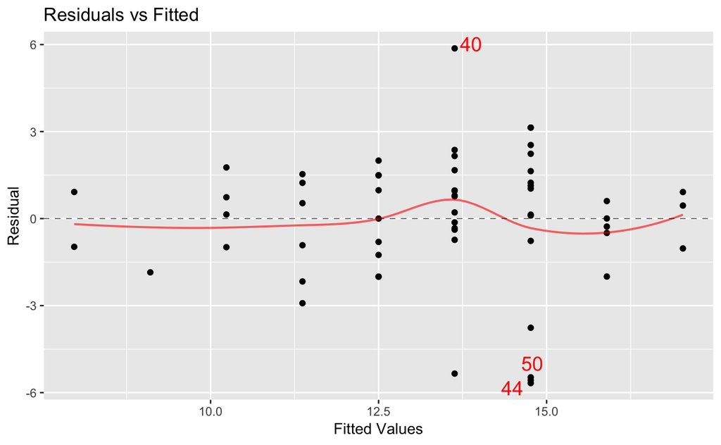

```r
mplot(model, which = 1) # plot the residuals and fitted values
```

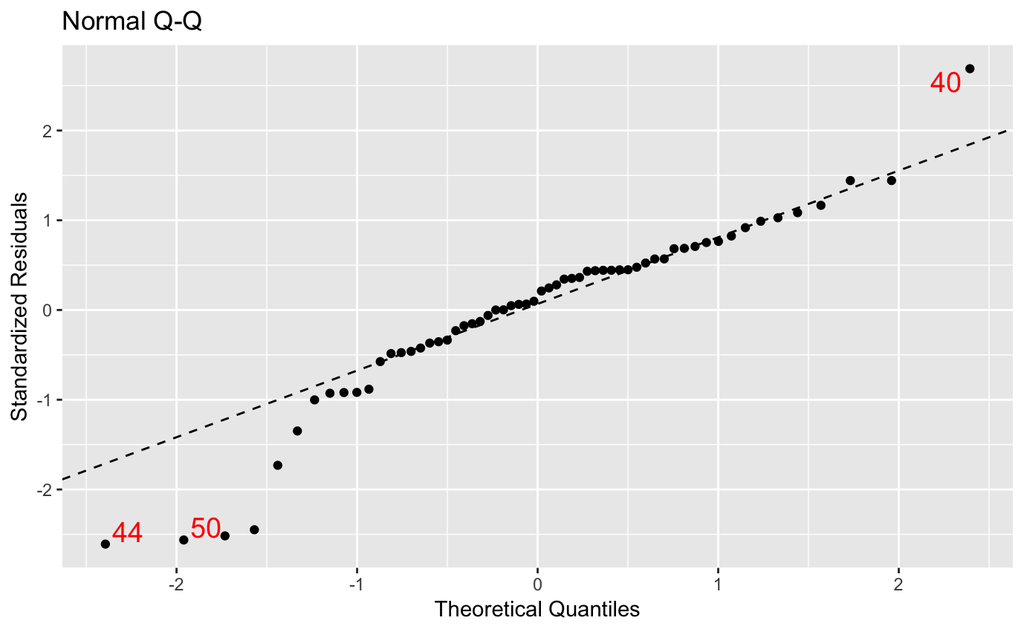

```r
mplot(model, which = 2) # plot the normal plot for model residuals
```

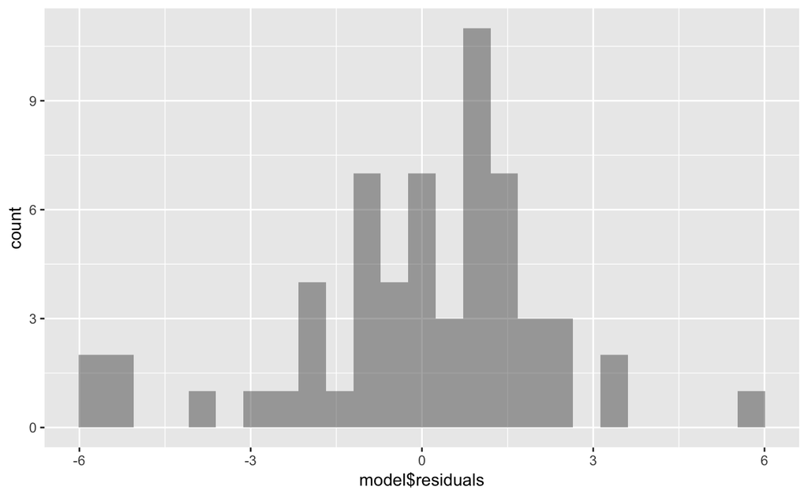

```r
gf_histogram(~model$residuals)
```

Based on the Residuals vs Fitted plot, I do not see any heteroskedasticity (fanning) trend. The graph seems to have a straight line close to the residual value of 0. From the normal quantile plot, I see that our residuals have longer tails than I have expected. Despite these longer tails, the graph seems to have residuals close to symmetric and roughly bell-shaped, as evidenced by the histogram of residuals.

#### Unusual points

Find the car in your sample with the largest (in magnitude) residual. What is the age and price of this car?

```r
# Price
used_cars$price[40]
```

```
[1] 19.5
```

```r
# Age
used_cars$age[40]
```

```
[1] 4
```

The price of this age is $19,500 and the age of the car is 4.

Use R to find this car’s studentized residual, leverage, and Cook’s distance. Would any of these values be considered unusual? Why or why not?

```r
# Studentized residual
rstudent(model)
```

```
            1             2             3             4             5             6
-0.1516072704  0.5202122768 -0.0598183986 -0.9262746552  0.5652446857 -0.8810772296
            7             8             9            10            11            12
-1.3577036703  0.4447206795 -0.1734268518  0.0657232033 -0.9186612987  0.7492632456
           13            14            15            16            17            18
 0.2781483924  0.3598720889  0.6798898695 -0.3509380267  1.4563799284 -0.4577153507
           19            20            21            22            23            24
-2.6435259632  0.0479621986 -0.9168010812 -1.7618422763  0.0964562303 -0.2283224515
           25            26            27            28            29            30
 0.4734003593  0.7616957049  1.0281312456  0.2440725074  0.0002077679  0.3415112202
           31            32            33            34            35            36
 1.0864527537  0.4392464275 -0.3326940959 -0.4719807188 -0.4208549649  1.4563799284
           37            38            39            40            41            42
 0.4454517009 -2.5635259014  0.9888082799  2.8492504432  0.9162957806  0.4284487796
           43            44            45            46            47            48
 0.7050321140 -2.7527390193  0.3493895467  1.1702421551 -0.5714546112  0.0620985064
           49            50            51            52            53            54
 0.4397029966 -2.6979447565  0.4351375208 -0.4820642441  0.8222219626  0.2097372762
           55            56            57            58            59            60
 0.0018627645 -1.0014389940  0.6840344890  0.5661532325 -0.1265401354 -0.3659885102
```

```r
# Leverage
hatvalues(model)
```

```
         1          2          3          4          5          6          7          8
0.01690842 0.02428976 0.01690842 0.04197065 0.02428976 0.09037851 0.03304437 0.13449489
         9         10         11         12         13         14         15         16
0.01690842 0.05656167 0.01982662 0.02428976 0.04197065 0.01690842 0.01982662 0.02428976
        17         18         19         20         21         22         23         24
0.02428976 0.05656167 0.02428976 0.02428976 0.01982662 0.02428976 0.01690842 0.04197065
        25         26         27         28         29         30         31         32
0.02428976 0.01690842 0.02428976 0.03304437 0.01982662 0.05656167 0.01690842 0.01690842
        33         34         35         36         37         38         39         40
0.01690842 0.13449489 0.03304437 0.02428976 0.01982662 0.01690842 0.01690842 0.01690842
        41         42         43         44         45         46         47         48
0.01982662 0.06995108 0.03304437 0.02428976 0.01690842 0.02428976 0.01982662 0.02428976
        49         50         51         52         53         54         55         56
0.01690842 0.02428976 0.01690842 0.06995108 0.05656167 0.06995108 0.04197065 0.03304437
        57         58         59         60
0.01982662 0.03304437 0.04197065 0.01982662
```

```r
# Cook's Distance
cooksplot(model)
```

[output not shown]

```
Error in cooksplot(model) : could not find function "cooksplot"
```

## Model: Use

#### Confidence interval

Compute and interpret a 95% confidence interval for the slope of your model.

```r
predict.lm(model, newdata=data.frame(age = -1.1321), interval="confidence", level = 0.95)
```

```
       fit      lwr      upr
1 19.44192 17.65771 21.22612
```

```r
confint(model, levle = 0.95)
```

```
                2.5 %     97.5 %
(Intercept) 16.710778 19.6096710
age         -1.448306 -0.8159665
```

We are 95% confident that the true slope is between -1.448306 and -0.8159665.

#### Coefficient of determination

Report the coefficient of determination (r-squared) and show how it can be computed using values from the ANOVA table. Interpret the value in context using a complete sentence.

```r
# Finding the R-squared using summary
summary(model)
```

```
Call:
lm(formula = price ~ age, data = used_cars)

Residuals:
    Min      1Q  Median      3Q     Max
-5.6718 -0.9313  0.3306  1.2335  5.8683

Coefficients:
            Estimate Std. Error t value Pr(>|t|)
(Intercept)  18.1602     0.7241  25.080  < 2e-16 ***
age          -1.1321     0.1579  -7.168 1.53e-09 ***
---
Signif. codes:  0 ‘***’ 0.001 ‘**’ 0.01 ‘*’ 0.05 ‘.’ 0.1 ‘ ’ 1

Residual standard error: 2.201 on 58 degrees of freedom
Multiple R-squared:  0.4697,    Adjusted R-squared:  0.4606
F-statistic: 51.38 on 1 and 58 DF,  p-value: 1.532e-09
```

```r
# Finding the R-squared using ANOVA table
ANOVA1 <- aov(price~ age, data = used_cars)
summary(ANOVA1) #R-squared = SSmodel / (SSTotal)
```

```
            Df Sum Sq Mean Sq F value   Pr(>F)
age          1  248.9  248.89   51.38 1.53e-09 ***
Residuals   58  281.0    4.84
---
Signif. codes:  0 ‘***’ 0.001 ‘**’ 0.01 ‘*’ 0.05 ‘.’ 0.1 ‘ ’ 1
```

248.9/(248.9+281) = 0.4697112663

#### Hypothesis tests

Test the strength of the linear relationship between age and price using all three methods discussed in class. For each of them, write the hypotheses (it’s fine to type them out without using special symbols), discuss how to calculate test statistic and show its value, indicate the reference distribution (t or F including degrees of freedom), and report the p-values. At the end, you can write one conclusion in context that reflects the conclusion based on all three p-values.

1. Test for correlation H0: rho = 0 Ha: rho ≠ 0

```r
cor.test(price ~ age, data = used_cars)
```

```
    Pearson's product-moment correlation

data:  price and age
t = -7.1677, df = 58, p-value = 1.532e-09
alternative hypothesis: true correlation is not equal to 0
95 percent confidence interval:
 -0.8000528 -0.5223396
sample estimates:
       cor
-0.6853614
```

t-statistics = {r(n-2)^(1/2)} / {(1-r<sup>2)</sup>(1/2)} = -7.1677 p-value = 1.532e-09 df = 58

2. Test for slope H0: beta1 = 0 Ha: beta1 ≠ 0

```r
summary(model)
```

```
Call:
lm(formula = price ~ age, data = used_cars)

Residuals:
    Min      1Q  Median      3Q     Max
-5.6718 -0.9313  0.3306  1.2335  5.8683

Coefficients:
            Estimate Std. Error t value Pr(>|t|)
(Intercept)  18.1602     0.7241  25.080  < 2e-16 ***
age          -1.1321     0.1579  -7.168 1.53e-09 ***
---
Signif. codes:  0 ‘***’ 0.001 ‘**’ 0.01 ‘*’ 0.05 ‘.’ 0.1 ‘ ’ 1

Residual standard error: 2.201 on 58 degrees of freedom
Multiple R-squared:  0.4697,    Adjusted R-squared:  0.4606
F-statistic: 51.38 on 1 and 58 DF,  p-value: 1.532e-09
```

t-statiscis = (predicted_beta1) / SE = -7.168 p-value = 1.532e-09 df = 58

3. ANOVA for regression

```r
summary(ANOVA1)
```

```
            Df Sum Sq Mean Sq F value   Pr(>F)
age          1  248.9  248.89   51.38 1.53e-09 ***
Residuals   58  281.0    4.84
---
Signif. codes:  0 ‘***’ 0.001 ‘**’ 0.01 ‘*’ 0.05 ‘.’ 0.1 ‘ ’ 1
```

F statistics = 51.38 Root of 51.38 is +-7.168 (t-statistics) p-value = 1.53e-09 df = 58

#### Predictions

Suppose you are interested in purchasing a car of this make and model that is five years old. For each of quantities below, show how to complete the calculations using formulas (with the correct numbers in the correct places). For the intervals, write a sentence that carefully interprets each in terms of car prices.

1. Predicted value for price of a car that is five years old Predicted price = 18.1602 - 1.1321(age) = 18.1602 - 1.1321(5) = $12,499.7
2. 90% confidence interval for the *mean price* of a car at this age

```r
conf.int <- predict.lm(model, newdata=data.frame(age = 5), interval="confidence", level = 0.90)
conf.int
```

```
       fit     lwr      upr
1 12.49954 11.9815 13.01759
```

```r
qt(0.9, 58)
```

```
[1] 1.296319
```

We are 90% confident that the average price of an average car age of 5 years is between $11,981.5 and $13,017.59

3. 90% prediction interval for the price of an *individual* car of this age.

```r
pred.int <- predict.lm(model, newdata=data.frame(age = 5), interval="prediction", level = 0.90)
pred.int
```

```
       fit      lwr      upr
1 12.49954 8.784133 16.21495
```

We are 90% confident that the individual price of an average car age of 5 years is between $8,784.133 and $16,214.95

# Discussion

According to your model, is there an age at which the car should be free? If so, find out what this age is and comment on what the ‘free car phenomenon’ says about the appropriateness of your model.

The age of 16.0411624415 car would result in a free price of a car. In real life, this does not make sense since age of 16 year old car is not free.